# homework_5

Peter

2026-02-09

Sec 5.9 Exercises # 3,6,8,10,13,18,20**,22** for problem 20, use both exact binomial calculations and normal approximation

### Problem 3

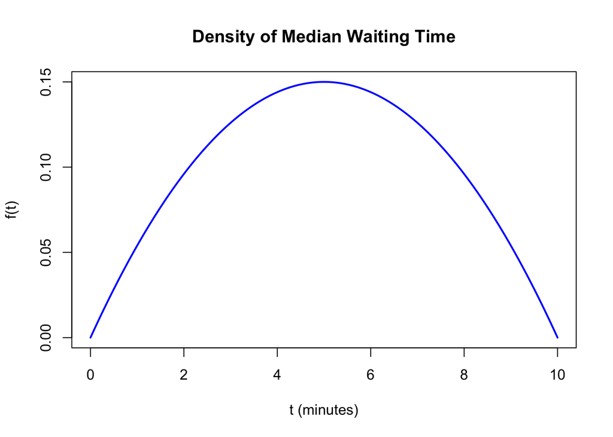

```r
t <- seq(0, 10, length.out = 300)
f <- 6 * t * (10 - t) / 1000
plot(t, f, type = "l", lwd = 2, col = "blue",
     xlab = "t (minutes)", ylab = "f(t)",
     main = "Density of Median Waiting Time")
```

$$P(5<T<7) = \int_{5}^{7}
\frac{6t(10-t)}{1000} \, dt = \frac{6}{1000} \cdot \left[5t^2 -
\frac{t^3}{3}\right]_5^7 = \frac{6}{1000} \cdot \frac{142}{3} =
0.284$$

$$F(T) = \int_{0}^{t}
\frac{6x(10-x)}{1000} \, dx = \frac{6}{1000} \cdot \left[5x^2 -
\frac{x^3}{3}\right]_0^t = \frac{t^2(15-t)}{500}$$

$$F(t) = \begin{cases}
0 & t \leq 0 \\
\frac{t^2(15-t)}{500} & 0 < t < 10 \\
1 & t \geq 10
\end{cases}$$

$$P(T>6) = 1 - F(6) = 1 -
\frac{324}{500} = 0.352$$

Using R to solve:

```r
uniroot(function(t) t^3 - 15*t^2 + 375, c(0,10))
```

```
## $root
## [1] 6.736455
##
## $f.root
## [1] 0.001738304
##
## $iter
## [1] 6
##
## $init.it
## [1] NA
##
## $estim.prec
## [1] 6.103516e-05
```

$t \approx 6.736455$

### Problem 6

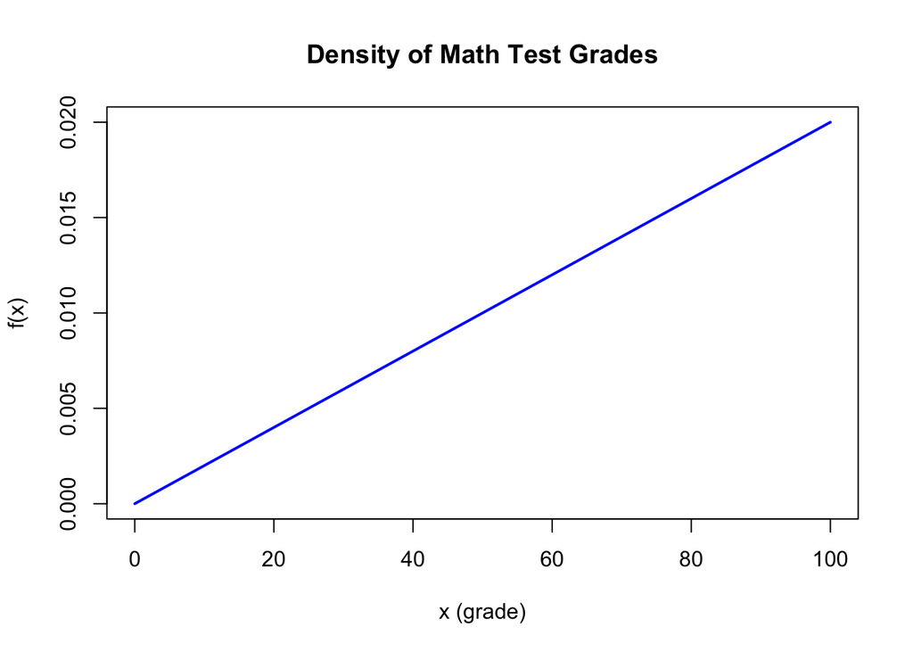

```r
x <- seq(0, 100, length.out = 300)
f <- x / 5000
plot(x, f, type = "l", lwd = 2, col = "blue",
     xlab = "x (grade)", ylab = "f(x)",
     main = "Density of Math Test Grades")
```

### Problem 8

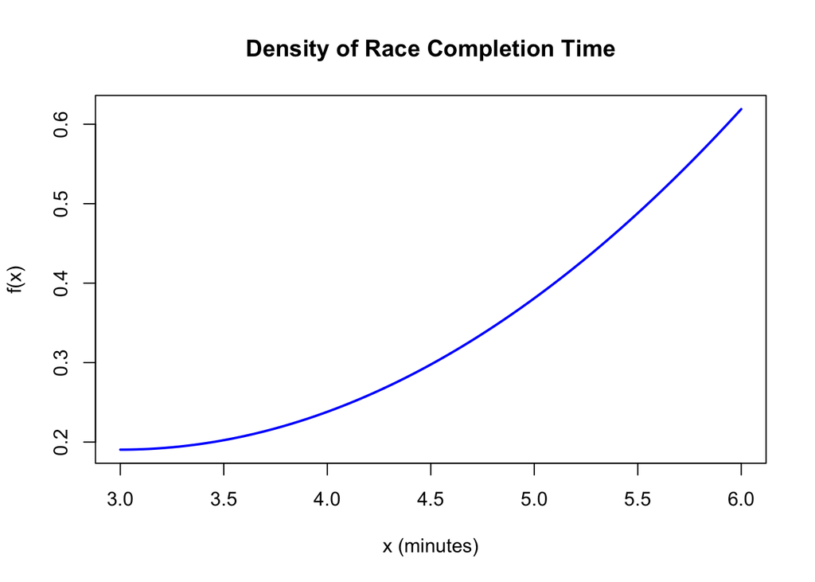

```r
x <- seq(3, 6, length.out = 300)
f <- (4 + (x - 3)^2) / 21
plot(x, f, type = "l", lwd = 2, col = "blue",
     xlab = "x (minutes)", ylab = "f(x)",
     main = "Density of Race Completion Time")
```

2. Slow times near 6 minutes are more common. The density is an upward-opening parabola: $f(3) = 4/21 \approx 0.190$ while $f(6) = 13/21 \approx 0.619$, so the density is much higher near 6 than near 3.
3. $$P(X < 4) = \int_{3}^{4} \frac{4 +
   (x-3)^2}{21} \, dx = \frac{1}{21} \left[4x +
   \frac{(x-3)^3}{3}\right]_3^4 = \frac{1}{21}\left(16 + \frac{1}{3} -
   12\right) = \frac{1}{21} \cdot \frac{13}{3} = \frac{13}{63} =
   0.2063$$
4. $$P(X > 5.5) = \int_{5.5}^{6}
   \frac{4 + (x-3)^2}{21} \, dx = \frac{1}{21}\left[4x +
   \frac{(x-3)^3}{3}\right]_{5.5}^{6} = \frac{1}{21}\left(24 + 9 - 22 -
   \frac{125}{24}\right) = \frac{1}{21}\left(11 - \frac{125}{24}\right) =
   \frac{1}{21} \cdot \frac{139}{24} = \frac{139}{504} =
   0.2758$$
5. $$F(x) = \int_3^x \frac{4 +
   (t-3)^2}{21}\,dt = \frac{1}{21}\left[4t + \frac{(t-3)^3}{3}\right]_3^x =
   \frac{1}{21}\left(4x + \frac{(x-3)^3}{3} - 12\right)$$

Set $F(m) = 0.5$:
$$\frac{1}{21}\left(4m + \frac{(m-3)^3}{3} -
12\right) = 0.5 \Rightarrow 4m + \frac{(m-3)^3}{3} - 12 = 10.5
\Rightarrow 4m + \frac{(m-3)^3}{3} = 22.5$$

```r
uniroot(function(m) 4*m + (m-3)^3/3 - 22.5, c(3, 6))
```

```
## $root
## [1] 4.979057
##
## $f.root
## [1] -1.065402e-06
##
## $iter
## [1] 6
##
## $init.it
## [1] NA
##
## $estim.prec
## [1] 6.103516e-05
```

### Problem 10

$$P(X < 90) = F(90) =
0.5934$$

$$P(120 < X < 180) = F(180) - F(120)
= 0.8347 - 0.6988 = 0.1359$$

The 95th percentile is where $F(x) = 0.95$. From the table, $F(270) = 0.9328$ and $F(300) = 0.9502$, so the 95th percentile is right around 300.

### Problem 13

Let $X \sim N(75, 10^2)$. Standardize with $Z = \frac{X - 75}{10}$.

1. $$P(X > 90) = P\left(Z > \frac{90 -
   75}{10}\right) = P(Z > 1.5) = 1 - P(Z \leq 1.5) =
   0.0668072$$

```r
1 - pnorm(1.5)
```

```
## [1] 0.0668072
```

2. $$P(70 < X < 80) = P\left(-0.5 <
   Z < 0.5\right) = P(Z < 0.5) - P(Z < -0.5) =
   0.3829249$$

```r
pnorm(0.5) - pnorm(-0.5)
```

```
## [1] 0.3829249
```

```r
qnorm(0.25)
```

```
## [1] -0.6744898
```

$z_{0.25} = -0.6744898$, so:
$$x = 75 + 10(-0.6744898) = 68.2551$$

The score 68.2551 is below 70, so the letter grade of the lower quartile is a D.

### Problem 18

Let $X \sim N(266, 16^2)$. Standardize with $Z = \frac{X - 266}{16}$.

$$P(X > 270) = P\left(Z > \frac{270
- 266}{16}\right) = P(Z > 0.25) = 1 - P(Z \leq 0.25) =
0.4012937$$

```r
1 - pnorm(0.25)
```

```
## [1] 0.4012937
```

```r
qnorm(0.25)
```

```
## [1] -0.6744898
```

```r
qnorm(0.75)
```

```
## [1] 0.6744898
```

```r
266 + 16*0.6744898
```

```
## [1] 276.7918
```

$z_{0.25} = -0.6744898$, $z_{0.75} = 0.6744898$, so:

$$\text{Lower} = 266 + 16(-0.6744898) =
255.2082$$
$$\text{Upper} = 266 +
16(0.6744898) = 276.7918$$

The middle 50% of pregnancy lengths is approximately between $(255.2082, 276.7918)$ days.

We need $P(X < x) = 0.90$.

```r
qnorm(0.90)
```

```
## [1] 1.281552
```

```r
266 + 16*1.281552
```

```
## [1] 286.5048
```

$z_{0.90} = 1.281552$, so:

$$x = 266 + 16(1.2816) = 286.5048 \text{
days}$$

### Problem 20

Let $X \sim \text{Binomial}(n=1000, p=0.5)$. $X \approx N(\mu, \sigma^2)$ where $\mu = np = 500$ and $\sigma = \sqrt{np(1-p)} = \sqrt{250} = 15.81139$.

1. $$E(X) = np = 1000 \cdot 0.5 = 500
   \text{ heads}$$

$$P(480 < X < 520) =
P\left(\frac{480 - 500}{15.81139} < Z < \frac{520 -
500}{15.81139}\right) = P(-1.264911 < Z < 1.264911) =
0.7940968$$

```r
20/15.81139
```

```
## [1] 1.264911
```

```r
pnorm(1.264911) - pnorm(-1.264911)
```

```
## [1] 0.7940968
```

```r
#BINOMIAL:
pbinom(519, 1000, 0.5) - pbinom(480, 1000, 0.5)
```

```
## [1] 0.7825517
```

$$P(X \geq 550) = P\left(Z \geq \frac{550
- 500}{15.81139}\right) = P(Z \geq 3.162) = 0.0007827029$$

```r
50/15.81139
```

```
## [1] 3.162277
```

```r
1 - pnorm(3.162277)
```

```
## [1] 0.0007827029
```

```r
# BINOMIAL:
1 - pbinom(549, 1000, 0.5)
```

```
## [1] 0.000865268
```

This probability is less than 0.1%. It’s very unlikely to get 550 or more heads with a fair coin, so it is very unlikely that the coin is actually fair.

BINOMIAL:

2. Using the exact binomial: $P(480 < X < 520) = 0.7825517$, close to the normal approximation of $0.7941$.

```r
pbinom(519, 1000, 0.5) - pbinom(480, 1000, 0.5)
```

```
## [1] 0.7825517
```

3. Using the exact binomial: $P(X \geq 550) = 0.000865268$, consistent with the normal approximation of $0.0008$.

```r
1 - pbinom(549, 1000, 0.5)
```

```
## [1] 0.000865268
```

### Problem 22

By CLT, $\bar{X} \approx N\left(\mu, \frac{\sigma^2}{n}\right)$ where $\mu = 4.83$, $\sigma = 0.84$, $n = 25$, so $\sigma_{\bar{X}} = \frac{0.84}{\sqrt{25}} = 0.168$.

1. $$P(\bar{X} > 5) = P\left(Z >
   \frac{5 - 4.83}{0.168}\right) = P(Z > 1.011905) =
   0.1557917$$

```r
0.17/0.168
```

```
## [1] 1.011905
```

```r
1 - pnorm(1.011905)
```

```
## [1] 0.1557917
```

```r
qnorm(0.05)
```

```
## [1] -1.644854
```

```r
qnorm(0.95)
```

```
## [1] 1.644854
```

```r
4.83 + 0.168*1.644854
```

```
## [1] 5.106335
```

$z_{0.05} = -1.644854$, $z_{0.95} = 1.644854$, so:
$$\text{Lower} = 4.83 + 0.168(-1.644854) =
4.553665$$
$$\text{Upper} = 4.83 +
0.168(1.644854) = 5.106335$$

We are 90% confident the mean completion time for 25 students is between $(4.553665, 5.106335)$ minutes.